# 2일차

## Request, Response

- Request: Client가 Server에게 자원을 요청하는 것
- Response: Clientr가 요청한 자원을 Server가 응답하는 것

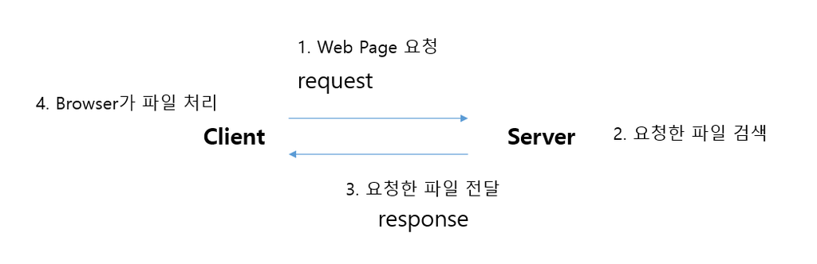

## Requests 모듈

- 정적인 웹 문서를 읽어오는 용도로 사용되는 3rd Party 모듈
- 표준 Library: urllib 모듈이 있는데, requests가 사용하기 더 쉽고 대중적으로 쓰임
- pip install requests
- 문서: https://docs.python-requests.org/en/latest/

```python
# 요청하는 도구인 requests 모듈 import
import requests

# 요청할 URL을 변수에 저장
url = 'http://www.naver.com'

# get() -> url 주소의 해당 페이지를 서버에 요청하고, 결과 응답을 받음
data = requests.get(url)
data

# 응답 코드 200 -> request에 정상 응답한 것
# 응답 코드 404 -> Not found를 의미함
```

```
<Response [200]>
```

```python
type(data)

# 반환된 자료형은 reqeusts.models.Response
```

```
requests.models.Response
```

```python
data.text[:200]
```

```
'\n<!doctype html>                          <html lang="ko" data-dark="false"> <head> <meta charset="utf-8"> <title>NAVER</title> <meta http-equiv="X-UA-Compatible" content="IE=edge"> <meta name="viewpo'
```

```python
data.encoding

# 데이터를 안전하게 전달하기 위해서 형태를 바꿔서 전달하는 것
```

```
'UTF-8'
```

```python
html = data.text
open('naver.html', 'w', encoding='utf-8').write(html)
```

```
196782
```

```python
url = 'https://api.sunrise-sunset.org/json?lat=36.7201600&lng=-4.4203400'

# json() -> JSON 데이터를 파이썬에서 다루기 쉽게 Dictionary&List 형태로 변환시킨 메서드
# JSON(JavaScript Object Notation): 파이썬의 Dictionary&List 형태로 정보를 교환하는 방식
data = requests.get(url).json()
data
```

```
{'results': {'sunrise': '7:26:17 AM',
  'sunset': '5:30:30 PM',
  'solar_noon': '12:28:24 PM',
  'day_length': '10:04:13',
  'civil_twilight_begin': '6:59:46 AM',
  'civil_twilight_end': '5:57:01 PM',
  'nautical_twilight_begin': '6:28:10 AM',
  'nautical_twilight_end': '6:28:37 PM',
  'astronomical_twilight_begin': '5:57:15 AM',
  'astronomical_twilight_end': '6:59:32 PM'},
 'status': 'OK'}
```

## 문자열 Formatting

- format + ing: 형식, 양식처럼 기본 틀이 갖춰짐
- f formatting: 문자열 처음 시작할 때(따옴표 밖에) 소문자 f를 붙임
- ex) f"hello world {num}"
- 문자열 안에서 { } 안에 변수 이름을 넣으면 변수의 값이 들어감

```python
a, b, c = 10, 11.5, 'abcd'
sample = f'하나 {a} 둘 {b} 셋 {c} 넷 다섯'
sample
```

```
'하나 10 둘 11.5 셋 abcd 넷 다섯'
```

```python
date = '2021-01-19'
url = f'https://api.sunrise-sunset.org/json?lat=36.7201600&lng=-4.4203400&date={date}'
data = requests.get(url).json()['results']
data
```

```
{'sunrise': '7:26:10 AM',
 'sunset': '5:30:46 PM',
 'solar_noon': '12:28:28 PM',
 'day_length': '10:04:36',
 'civil_twilight_begin': '6:59:41 AM',
 'civil_twilight_end': '5:57:15 PM',
 'nautical_twilight_begin': '6:28:05 AM',
 'nautical_twilight_end': '6:28:51 PM',
 'astronomical_twilight_begin': '5:57:11 AM',
 'astronomical_twilight_end': '6:59:45 PM'}
```

```python
# 남산: 37.55366911,126.98103009

def by_date(date):
    url = f'https://api.sunrise-sunset.org/json?lat=37.55366911&lng=126.98103009&date={date}'
    return requests.get(url).json()['results']

by_date('2021-12-19')

# 날짜가 바뀌면 내 컴퓨터에 다른 정보가 옴 -> 요청이 다르면 응답이 달라짐
```

```
{'sunrise': '10:40:27 PM',
 'sunset': '8:17:43 AM',
 'solar_noon': '3:29:05 AM',
 'day_length': '09:37:16',
 'civil_twilight_begin': '10:12:43 PM',
 'civil_twilight_end': '8:45:27 AM',
 'nautical_twilight_begin': '9:39:53 PM',
 'nautical_twilight_end': '9:18:17 AM',
 'astronomical_twilight_begin': '9:08:00 PM',
 'astronomical_twilight_end': '9:50:10 AM'}
```

## Data Frame

- Data가 틀에 맞게 저장된 형태
- ex) 스프레드 시트, 엑셀, 테이블 등 분야마다 다르게 불림
- 파이썬의 List와 Dictionary로 Data Frame을 표현할 수 있음
- List: 데이터가 순서(index)대로 저장되어 있는 것
- Dictionary: 키와 값이 쌍으로 저장된 것

```python
# 아무것도 없는 빈 리스트 만들기
sample_list = []

# 키가 동일한 Dictionary를 여러 개 저장
sample_list.append({'date':'2020-01-01', 'yo_il':'wed'})
sample_list.append({'date':'2020-01-02', 'yo_il':'thu'})
sample_list.append({'date':'2020-01-03', 'yo_il':'fri'})

sample_list
```

```
[{'date': '2020-01-01', 'yo_il': 'wed'},
 {'date': '2020-01-02', 'yo_il': 'thu'},
 {'date': '2020-01-03', 'yo_il': 'fri'}]
```

```python
# pandas라는 이름의 도구를 불러와 pd라는 축약어로 사용
# Pandas: 파이썬에서 데이터 프레임을 다루는 도구
import pandas as pd

# sample_list를 기반으로 Data Frame 생성해 df에 저장
df = pd.DataFrame(sample_list)
df

# Column(date, yo_il)을 한 번만 표현할 수 있음
```

|  | date | yo_il |
| --- | --- | --- |
| 0 | 2020-01-01 | wed |
| 1 | 2020-01-02 | thu |
| 2 | 2020-01-03 | fri |

```python
df.to_csv('sample.csv', index=False)
# 파일 저장 위치: C:\Users\user
# 만약 permission Error 발생한다면?
# 파일을 열어서 작업하고 있는데(엑셀, 한셀 등) pandas에서 해당 파일의 이름으로 저장하면,
# 원본 파일을 덮어쓰기하는 셈이 되므로 권한이 없다고 함
# 권한 에러가 발생한 경우 엑셀 등에서 데이터 파일을 열어보고 있지 않나 확인

# index 정보는 파일에 이미 있음 -> 관행적으로 파일에 따로 저장하지 않음
```

```python
# '\' 대신 '/'로 위치 정보를 나타냄
path = 'C:/Users/KGITBank/Desktop/here'
df.to_csv(path + '/' + 'sample.csv', index=False)
```

```python
# 파일에 저장된 데이터 불러오기
df1 = pd.read_csv('sample.csv')
df1
```

|  | date | yo_il |
| --- | --- | --- |
| 0 | 2020-01-01 | wed |
| 1 | 2020-01-02 | thu |
| 2 | 2020-01-03 | fri |

```python
sample_list = []

sample_list.append(by_date('2020-01-01'))
sample_list.append(by_date('2020-01-02'))
sample_list.append(by_date('2020-01-03'))

sample_list
```

```
[{'sunrise': '10:45:13 PM',
  'sunset': '8:25:14 AM',
  'solar_noon': '3:35:14 AM',
  'day_length': '09:40:01',
  'civil_twilight_begin': '10:17:36 PM',
  'civil_twilight_end': '8:52:52 AM',
  'nautical_twilight_begin': '9:44:53 PM',
  'nautical_twilight_end': '9:25:35 AM',
  'astronomical_twilight_begin': '9:13:05 PM',
  'astronomical_twilight_end': '9:57:23 AM'},
 {'sunrise': '10:45:23 PM',
  'sunset': '8:26:01 AM',
  'solar_noon': '3:35:42 AM',
  'day_length': '09:40:38',
  'civil_twilight_begin': '10:17:47 PM',
  'civil_twilight_end': '8:53:37 AM',
  'nautical_twilight_begin': '9:45:05 PM',
  'nautical_twilight_end': '9:26:19 AM',
  'astronomical_twilight_begin': '9:13:19 PM',
  'astronomical_twilight_end': '9:58:05 AM'},
 {'sunrise': '10:45:31 PM',
  'sunset': '8:26:49 AM',
  'solar_noon': '3:36:10 AM',
  'day_length': '09:41:18',
  'civil_twilight_begin': '10:17:57 PM',
  'civil_twilight_end': '8:54:23 AM',
  'nautical_twilight_begin': '9:45:17 PM',
  'nautical_twilight_end': '9:27:03 AM',
  'astronomical_twilight_begin': '9:13:31 PM',
  'astronomical_twilight_end': '9:58:49 AM'}]
```

```python
pd.DataFrame(sample_list)
```

|  | sunrise | sunset | solar_noon | day_length | civil_twilight_begin | civil_twilight_end | nautical_twilight_begin | nautical_twilight_end | astronomical_twilight_begin | astronomical_twilight_end |
| --- | --- | --- | --- | --- | --- | --- | --- | --- | --- | --- |
| 0 | 10:45:13 PM | 8:25:14 AM | 3:35:14 AM | 09:40:01 | 10:17:36 PM | 8:52:52 AM | 9:44:53 PM | 9:25:35 AM | 9:13:05 PM | 9:57:23 AM |
| 1 | 10:45:23 PM | 8:26:01 AM | 3:35:42 AM | 09:40:38 | 10:17:47 PM | 8:53:37 AM | 9:45:05 PM | 9:26:19 AM | 9:13:19 PM | 9:58:05 AM |
| 2 | 10:45:31 PM | 8:26:49 AM | 3:36:10 AM | 09:41:18 | 10:17:57 PM | 8:54:23 AM | 9:45:17 PM | 9:27:03 AM | 9:13:31 PM | 9:58:49 AM |

## 시간을 다루는 도구 time

- 수집 시간을 늘려서 상대 서버의 자원을 적게 사용할 수 있게 함(눈치 보기)
- 의도적으로 코드 실행 시간 늦춤
- ** 웹 크롤링에서는 일반적으로 프로그래밍상 말하는 빠른 코드가 좋은 코드라는 인식, 논리에 해당하지 않음

```python
import time

for i in range(5):
    print(i)
    time.sleep(2) # 2초동안 멈추고 실행
```

```
0
1
2
3
4
```

```python
for date in pd.date_range('2021-01-01', '2021-01-10'):
    #print(date)
    date_str = str(date)[:10]
    print(date_str)
```

```
2021-01-01
2021-01-02
2021-01-03
2021-01-04
2021-01-05
2021-01-06
2021-01-07
2021-01-08
2021-01-09
2021-01-10
```

```python
# Q) 2021-01-01 ~ 2021-03-01까지의 데이터를 모아서 sample_dates.csv 파일에 저장하세요.
#    이 데이터를 이용하는 사람이 되었다고 가정했을 때, 데이터 수집을 지시하는 경우와
#    수집을 지시받은 경우의 관점에서 sample_dates.csv 파일이 사용에 문제가 있는지 고민하세요.
#    문제가 있으면? 혹은 없으면? 그 근거는 무엇인가?

import time
import pandas as pd

sample_list = []

for date in pd.date_range('2021-01-01', '2021-01-10'):
    date_str = str(date)[:10]
    sample_list.append(by_date(date_str))
    #time.sleep(1)

pd.DataFrame(sample_list).to_csv('sample_dates.csv', index=False)

# A) 코드를 작성한 사람은 Row 별로 날짜라고 구분이 가능한데, 다른 분들은 알 수 있는 정보가 없다.
#    즉 Row와 Row를 구분할 수 있는 정보가 없다.
#    날짜와 관련된 Column을 새로 만들어 Row 별로 날짜 정보를 추가하면 좋겠다.
```

```python
by_date(date_str)
```

```
{'sunrise': '10:45:23 PM',
 'sunset': '8:33:43 AM',
 'solar_noon': '3:39:33 AM',
 'day_length': '09:48:20',
 'civil_twilight_begin': '10:18:06 PM',
 'civil_twilight_end': '9:01:00 AM',
 'nautical_twilight_begin': '9:45:42 PM',
 'nautical_twilight_end': '9:33:24 AM',
 'astronomical_twilight_begin': '9:14:08 PM',
 'astronomical_twilight_end': '10:04:58 AM'}
```

```python
def by_date_2(date):
    url = f'https://api.sunrise-sunset.org/json?lat=37.55366911&lng=126.98103009&date={date}'
    sun_data = requests.get(url).json()['results']
    sun_data['date'] = date
    return sun_data

by_date_2('2021-01-01')
```

```
{'sunrise': '10:45:21 PM',
 'sunset': '8:25:49 AM',
 'solar_noon': '3:35:35 AM',
 'day_length': '09:40:28',
 'civil_twilight_begin': '10:17:44 PM',
 'civil_twilight_end': '8:53:26 AM',
 'nautical_twilight_begin': '9:45:02 PM',
 'nautical_twilight_end': '9:26:08 AM',
 'astronomical_twilight_begin': '9:13:15 PM',
 'astronomical_twilight_end': '9:57:55 AM',
 'date': '2021-01-01'}
```

```python
sample_list = []

for date in pd.date_range('2021-01-01', '2021-01-10'):
    date_str = str(date)[:10]
    sample_list.append(by_date_2(date_str))
    time.sleep(2)

pd.DataFrame(sample_list).to_csv('sample_dates.csv', index=False)
```

## JSON, HTML, XML

#### JSON(JavaScript Object Notation)

- Key:Value가 쌍으로 이뤄진 데이터를 저장하거나 전송할 때 사용되는 개방형 표준 포멧
- Javascript에서 객체를 만들 때 사용하는 표현식
- JSON 표현식은 사람과 기계 모두 이해하기 쉬우며 용량이 적음

#### HTML(HyperText Markup Language)

- 웹사이트에서 화면에 표시되는 정보를 약속한 것
- 태그라는 개념으로 태그들이 계층적인 구조를 갖음
- Hypertext: 단순 텍스트 이상의 링크 등의 개념이 포함된 텍스트
- Markup: 꺽쇠(<, >)로 이뤄진 태그를 사용하는 규격

#### XML(eXtensible Markup Language)

- HTML의 한계를 극복할 목적으로 만들어진 다목적 마크업 언어
- XML는 HTML처럼 데이터를 보여주는 목적이 아닌, 데이터를 저장하고 전달할 목적으로만 만들어짐
- XML 태그는 HTML 태그처럼 미리 정의되어 있지 않고, 사용자가 직접 정의할 수 있음

#### Dictionary처럼 다룰 수 있는 것들

- JSON, XML

#### Dictionary가 아닌 방식으로 다룰 수 있는 것들

- XML, HTML